# IE423 - QUALITY ENGINEERING - FALL 2023 - PROJECT PART 2

- Fatmanur Yaman - 2019402204
- Ömer Coşkun - 2019402177
- Hüseyin Emre Bacak - 2021402279

# Introduction

In this assignment, we investigated the relationship between pairs trading methodology and control charts. For this purpose, we have used the hourly time series data of BIST30 stock indices. Before delving into further details, it might be beneficial to define pairs trading. Pairs trading is a trading method based on maximizing profits from the relative movements of two highly correlated stocks. If one stock is underperforming compared to the other, the non-underperforming stock is sold entirely, and the underperforming one is bought. This approach aims to create a method that is minimally affected by the overall market movements. When it comes to the relevance of control charts to this topic, initially, we identified the two stock pairs that were most highly correlated based on the provided data. To do this, we created a correlation matrix and visually represented it as a heatmap to utilize the results of the correlation matrix. Subsequently, using the individual stocks within these two pairs, we established a linear regression model. Statistically, the residuals from this model represent the deviation from the expected relationship between the stocks in the pair. These residuals can be plotted on a control chart to monitor the deviation of the stock pair from the expected relationship. Deviations outside the limits represent potential trading opportunities.

# Executive Summary

In this study, two highly correlated stock pairs were selected from the BIST30 stock index. These pairs were interpreted in two different ways: under the constant variance assumption and through time series analysis. A pairs trading simulation was conducted based on these interpretations. Additionally, the study highlighted the relationship between the control charts used in this research and the methodologies of statistical process control with both quality engineering and financial strategies. Comparative analyses of all these procedures were conducted within the scope of this study.

# Data Preprocessing and Visualization

First of all, to understand the general situation, the data regarding each stock is being plotted over years in one chart.

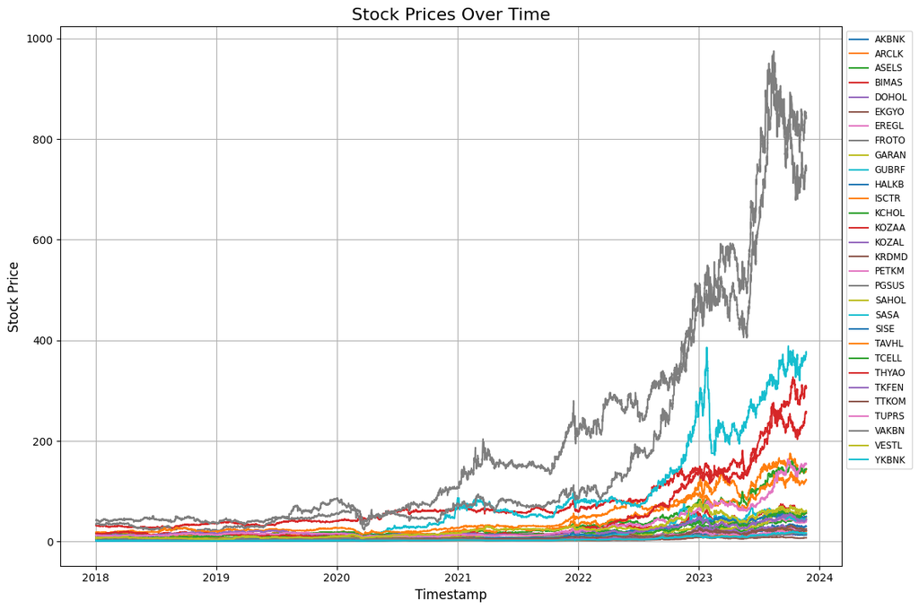

```python
import os
import pandas as pd
import numpy as np
import matplotlib.pyplot as plt
import seaborn as sns
from sklearn.linear_model import LinearRegression
import matplotlib.dates as mdates
from statsmodels.tsa.statespace.sarimax import SARIMAX
import warnings
warnings.filterwarnings('ignore')

# bist30 file path
folder_path = "bist30/"

# Getting a list of all CSV files in the folder
csv_files = sorted([file for file in os.listdir(folder_path) if file.endswith('.csv')])

# Initializing an empty list to store DataFrames
dfs = []

# Looping through each CSV file and reading its data into a DataFrame
for file in csv_files:
    file_path = os.path.join(folder_path, file)
    df = pd.read_csv(file_path)
    dfs.append(df)

# Concatenate all DataFrames in the list along the rows
df = pd.concat(dfs, ignore_index=True)

# Convert the timestamp column to datetime format
df['timestamp'] = pd.to_datetime(df['timestamp'])

# Sort DataFrame by timestamp
df.sort_values(by='timestamp', inplace=True)

# Plotting
plt.figure(figsize=(12, 8))
for short_name, group in df.groupby('short_name'):
    plt.plot(group['timestamp'], group['price'], label=short_name)

plt.title('Stock Prices Over Time', fontsize=16)
plt.xlabel('Timestamp', fontsize=12)
plt.ylabel('Stock Price', fontsize=12)
plt.legend(loc='upper left', bbox_to_anchor=(1, 1), fontsize='small')
plt.grid(True)
plt.tight_layout()

# Show the plot
plt.show()
```

# Pairs Selection

In order to decide on the stock pairs to consider for pairs deciding, we will use a **correlation matrix** to identify highly correlated stocks. The highly correlated 2 pairs are chosen as **(PGSUS,THYAO) and (GARAN,AKBNK).** Then, the selected pairs are plotted together over the years.

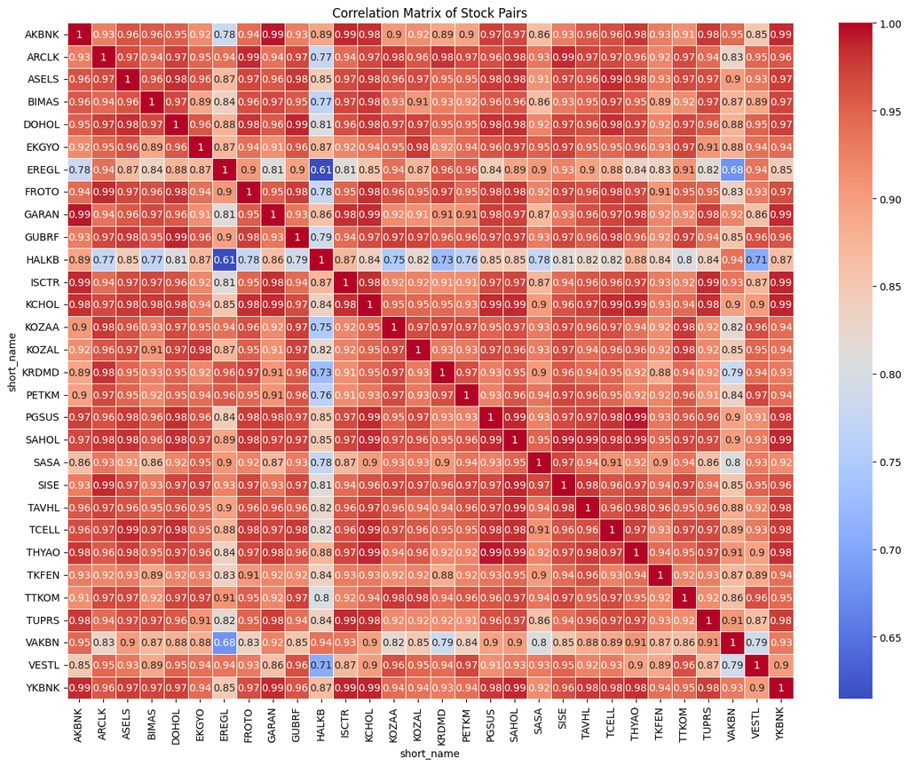

```python
# Pivot the dataframe to have each stock as a column
pivot_df = df.pivot(index='timestamp', columns='short_name', values='price')

# Calculate the correlation matrix
correlation_matrix = pivot_df.corr()

# Plot
plt.figure(figsize=(16, 12))
sns.heatmap(correlation_matrix, annot=True, cmap='coolwarm', linewidths=.5)
plt.title('Correlation Matrix of Stock Pairs')
plt.show()
```

```python
# Find the two pairs with the highest correlation, excluding duplicates
max_corr = correlation_matrix.abs().unstack()
max_corr = max_corr[max_corr < 1]  # Exclude self-correlations
max_corr = max_corr.sort_values(ascending=False)

# Filter out pairs with the same stocks
unique_pairs = set()
top_pairs = []

for pair in max_corr.index:
    stock1, stock2 = pair
    reverse_pair = (stock2, stock1)

    if pair not in unique_pairs and reverse_pair not in unique_pairs:
        unique_pairs.add(pair)
        unique_pairs.add(reverse_pair)
        top_pairs.append(pair)

# Extract the names of the top two pairs
pair1, pair2 = top_pairs[:2]
print(f'Top Correlated Pairs:')
print(f'{pair1[0]} and {pair1[1]} with correlation {correlation_matrix.loc[pair1[0], pair1[1]]}')
print(f'{pair2[0]} and {pair2[1]} with correlation {correlation_matrix.loc[pair2[0], pair2[1]]}')
```

```
Top Correlated Pairs:
PGSUS and THYAO with correlation 0.9930364101033123
GARAN and AKBNK with correlation 0.9926187726368645
```

Let's also visualize the plots of PGSUS vs THYAO and GARAN vs AKBNK to make also visually confirm the pairs selection.

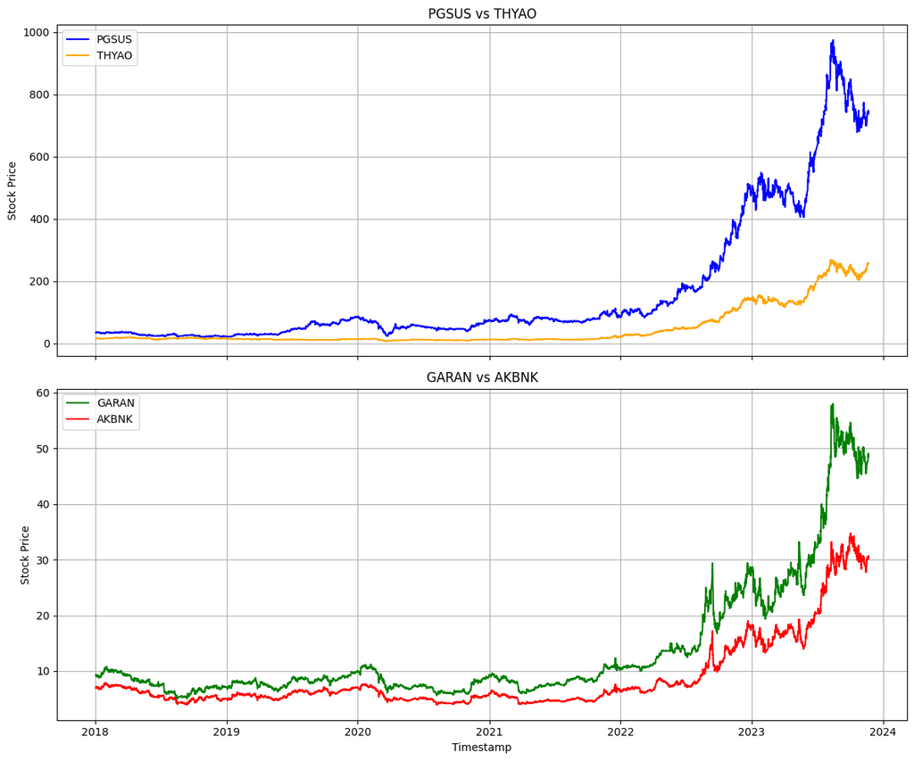

```python
# Selected pairs
pair1 = ('PGSUS', 'THYAO')
pair2 = ('GARAN', 'AKBNK')

# Set up subplots with spacing
fig, axes = plt.subplots(nrows=2, ncols=1, figsize=(12, 10), sharex=True)

# Plotting pair 1 (PGSUS vs THYAO)
axes[0].plot(pivot_df.index, pivot_df[pair1[0]], label=pair1[0], color='blue')
axes[0].plot(pivot_df.index, pivot_df[pair1[1]], label=pair1[1], color='orange')
axes[0].set_title(f'{pair1[0]} vs {pair1[1]}')
axes[0].set_ylabel('Stock Price')
axes[0].legend()
axes[0].grid(True)

# Plotting pair 2 (GARAN vs AKBNK)
axes[1].plot(pivot_df.index, pivot_df[pair2[0]], label=pair2[0], color='green')
axes[1].plot(pivot_df.index, pivot_df[pair2[1]], label=pair2[1], color='red')
axes[1].set_title(f'{pair2[0]} vs {pair2[1]}')
axes[1].set_xlabel('Timestamp')
axes[1].set_ylabel('Stock Price')
axes[1].legend()
axes[1].grid(True)
plt.tight_layout()
plt.show()
```

# Task 1. Basic Pairs Trading Strategy Using Constant Variance Assumption

Linear regression is a statistical method used to model the relationship between a dependent variable and one or more independent variables by fitting a linear equation to the observed data. The idea behind the pairs trading is simultaneously buying and selling of two correlated or related financial instruments. Thus, the profit gained from pairs trading depends on the relation between two stocks. From the linear regression point of view, one of the stocks can be interpreted as a dependent variable and the other one is the independent one. The linear regression will detect the mutual relationship between the pair.

After choosing the pair that shows positive correlation by using linear regression, the residuals should be examined since the maximum profit is the main aim. The deviations from the predicted linear regression line are the points where the relationship in the pair is broken. Thus, the residuals should be examined by using control charts.

### a. Constructing The Linear Regression Model

**Warning:** It is crucial to not to use future data to set up control charts since that data is unknown to us in simulation model. Therefore for each quarter, we will update our control charts so that for each quarter of trading, we use the control charts with 3 sigma control limits of the previous quarter. By doing so, we believe that our control charts will be somewhat inflation adjusted, considering the volatile economy of Turkey in recent years.

```python
# Selected pairs
pair1 = ('PGSUS', 'THYAO')
pair2 = ('GARAN', 'AKBNK')

df_first_quarter = pd.read_csv(f"bist30/{csv_files[0]}")

# Convert the timestamp column to datetime format
df_first_quarter['timestamp'] = pd.to_datetime(df_first_quarter['timestamp'])

# Sort DataFrame by timestamp
df_first_quarter.sort_values(by='timestamp', inplace=True)
# assign a column for each stock
df_first_quarter = df_first_quarter.pivot(index='timestamp', columns='short_name', values='price')

# "GARAN" and "PGSUS" has 5 null values
# We fill null values with the previous row's price for "GARAN" and "PGSUS"
pivot_df['GARAN'] = df_first_quarter['GARAN'].fillna(method='ffill')
pivot_df['PGSUS'] = df_first_quarter['PGSUS'].fillna(method='ffill')

# Function for linear regression modeling and residual calculation
def linear_regression_and_residuals(pair, df):
    X = df[pair[0]].values.reshape(-1, 1)
    y = df[pair[1]].values
    reg = LinearRegression().fit(X, y)
    df['residuals_' + pair[0] + '_' + pair[1]] = y - reg.predict(X)
    return df, reg

# Linear regression modeling to each pair
df_first_quarter, reg = linear_regression_and_residuals(pair1, df_first_quarter)
df_first_quarter, reg = linear_regression_and_residuals(pair2, df_first_quarter)
```

### b. Setting Up Control Charts

**Warning:** It is crucial to not to use future data to set up control charts since that data is unknown to us in simulation model. Therefore for each quarter, we will update our control charts so that for each quarter of trading, we use the control charts with 3 sigma control limits of the previous quarter. By doing so, we believe that our control charts will be somewhat inflation adjusted, considering the volatile economy of Turkey in recent years.

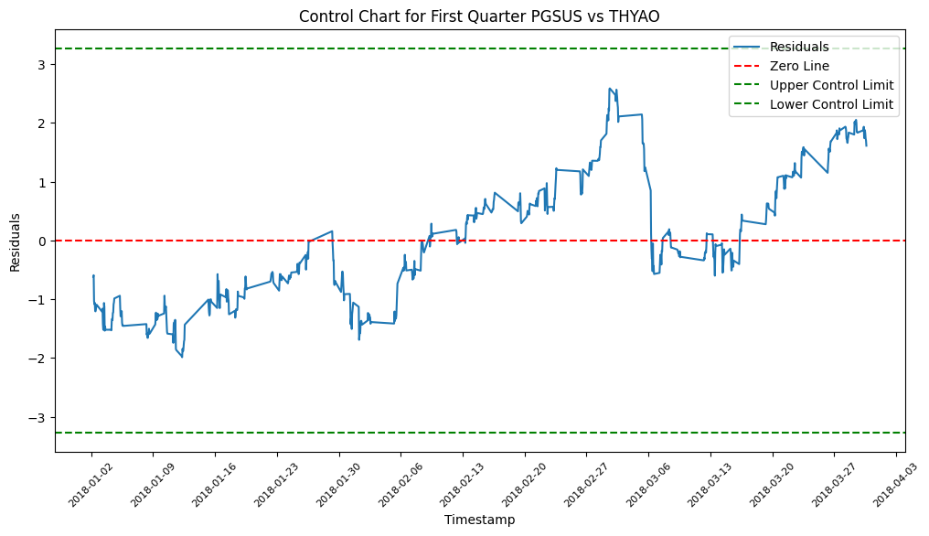

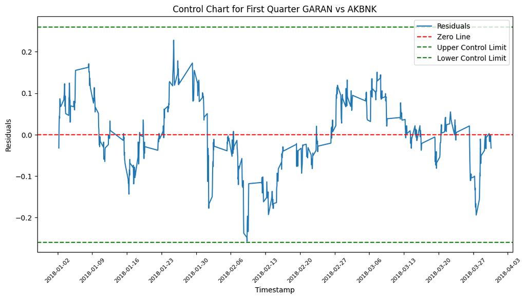

```python
# Function for plotting control charts
def plot_control_chart(pair, df):
    plt.figure(figsize=(12, 6))
    plt.plot(df.index, df['residuals_' + pair[0] + '_' + pair[1]], label='Residuals')
    plt.axhline(y=0, color='r', linestyle='--', label='Zero Line')
    plt.axhline(y=df['residuals_' + pair[0] + '_' + pair[1]].std() * 3, color='g', linestyle='--', label='Upper Control Limit')
    plt.axhline(y=-df['residuals_' + pair[0] + '_' + pair[1]].std() * 3, color='g', linestyle='--', label='Lower Control Limit')
    plt.title('Control Chart for First Quarter ' + pair[0] + ' vs ' + pair[1])
    plt.xlabel('Timestamp')
    plt.ylabel('Residuals')
    plt.legend()
    # Format x-axis as weekly
    plt.gca().xaxis.set_major_locator(mdates.WeekdayLocator())
    plt.gca().xaxis.set_major_formatter(mdates.DateFormatter('%Y-%m-%d'))
    plt.xticks(rotation=45, fontsize=8)
    plt.show()

# Plotting control chart for each pair
plot_control_chart(pair1, df_first_quarter)
plot_control_chart(pair2, df_first_quarter)
```

### c. Simulation for GARAN - AKBNK pair

For every quarter starting from tenth, we used the very past data to construct control charts. We fit a linear regression model using that data. After running that model, we used the corresponding residuals to construct a control chart. We adjusted the data points using the control limits so that the process was not out of control. After that, we used the current quarter’s data, which are not included in control charts, for trading purposes. Again, we fit a linear regression model and compared the residuals with control charts constructed with related control limits.

**Note:** We started the simulations for both tasks from the quarter 10. The reason behind this approach can be explained as follows: Since we need enough data to fit a SARIMAX model and appropriately forecast for next quarters, we started our simulation from that point. For consistency, we also started the simulation under constant variance assumption from the same point.

```python
def get_df_of_quarter(quarter_number):
    df_quarter = pd.read_csv(f"bist30/{csv_files[quarter_number]}")
    # Convert the timestamp column to datetime format
    df_quarter['timestamp'] = pd.to_datetime(df_quarter['timestamp'])
    # Sort DataFrame by timestamp
    df_quarter.sort_values(by='timestamp', inplace=True)
    # assign a column for each stock
    df_quarter = df_quarter.pivot(index='timestamp', columns='short_name', values='price')
    # fill nan values with the previous value
    df_quarter['GARAN'] = df_quarter['GARAN'].fillna(method='ffill')
    df_quarter['PGSUS'] = df_quarter['PGSUS'].fillna(method='ffill')
    return df_quarter

# Function to simulate pairs trading
def simulate_pairs_trading(pair, capital=100000):

    initialValue0 = get_df_of_quarter(10)[pair[0]].values[0]
    finalValue0 = get_df_of_quarter(23)[pair[0]].values[-1]

    initialValue1 = get_df_of_quarter(10)[pair[1]].values[0]
    finalValue1 = get_df_of_quarter(23)[pair[1]].values[-1]

    # Initialize variables
    current_quarter = 1
    trades = []
    stock_at_hand = {pair[0]: 0, pair[1]: 0}

    while current_quarter < len(csv_files):
        if current_quarter < 10:
            current_quarter += 1
            continue
        # get the previous quarter's data to be used to construct control charts
        df_previous_quarter = get_df_of_quarter(current_quarter-1)
        # get linear regression modeling of stock pairs
        df_previous_quarter, reg = linear_regression_and_residuals(pair, df_previous_quarter)
        # set the control limits
        columnName = 'residuals_' + pair[0] + '_' + pair[1]
        upperControlLimit = df_previous_quarter[columnName].std() * 3
        lowerControlLimit = -upperControlLimit
        # we must adjust the data until none of them are out of control limits
        out_of_control = True
        while out_of_control:
            df_previous_quarter = df_previous_quarter[(df_previous_quarter[columnName] > lowerControlLimit) & (df_previous_quarter[columnName] < upperControlLimit)]
            # setting the control limits
            upperControlLimit = df_previous_quarter[columnName].std() * 3
            lowerControlLimit = -upperControlLimit
            if len(df_previous_quarter) == len(df_previous_quarter[(df_previous_quarter[columnName] > lowerControlLimit) & (df_previous_quarter[columnName] < upperControlLimit)]):
                out_of_control = False

        # now that system is not out of control, we can continue
        # get current quarters data for trading (not included in control charts)
        df_current_quarter = get_df_of_quarter(current_quarter)

        X = df_current_quarter[pair[0]].values.reshape(-1, 1)
        y = df_current_quarter[pair[1]].values

        # calculate residuals for current quarter
        df_current_quarter[columnName] = y - reg.predict(X)

        # Define trading signals based on control chart
        # Future quarters must not be used
        df_current_quarter['buy_signal'] = df_current_quarter[columnName] < lowerControlLimit
        df_current_quarter['sell_signal'] = df_current_quarter[columnName] > upperControlLimit
        # Simulate trades
        for index, row in df_current_quarter.iterrows():
            # Buy signal for pair 1
            if row['buy_signal'] and stock_at_hand[pair[1]] == 0:
                # liquidate and buy stock pair 1
                capital = row[pair[0]] * stock_at_hand[pair[0]] + capital
                if row[pair[0]] != 0: trades.append([index, pair[0], "SELL", np.round(capital, 2)])
                trades.append([index, pair[1], "BUY", np.round(capital, 2)])
                stock_at_hand = {pair[0]: 0, pair[1]: capital / row[pair[1]]}
                capital = 0
            # Sell signal for pair 1
            elif row['sell_signal'] and stock_at_hand[pair[1]] > 0:
                # liquidate and buy stock pair 0
                capital = row[pair[1]] * stock_at_hand[pair[1]] + capital
                if row[pair[1]] != 0: trades.append([index, pair[1], "SELL", np.round(capital, 2)])
                trades.append([index, pair[0], "BUY", np.round(capital, 2)])
                stock_at_hand = {pair[0]: capital / row[pair[0]], pair[1]: 0}
                capital = 0

        final_values = pd.DataFrame(df_current_quarter.iloc[-1]).transpose()
        final_pair0 = float(final_values[pair[0]])
        final_pair1 = float(final_values[pair[1]])

        # Finally, get the value of portfolio at the end the of quarter
        end_of_quarter_worth = capital + stock_at_hand[pair[0]] * final_pair0 + stock_at_hand[pair[1]] * final_pair1
        print(f"End of quarter {current_quarter} portfolio net worth: ₺", np.round(end_of_quarter_worth, 2))
        # go to the next quarter
        current_quarter += 1
    final_worth = stock_at_hand[pair[0]] * final_pair0 + stock_at_hand[pair[1]] * final_pair1
    print(f"Holding {pair[0]}:", np.round(100000 * finalValue0 / initialValue0, 2))
    print(f"Holding {pair[1]}:", np.round(100000 * finalValue1 / initialValue1, 2))
    return np.round(final_worth, 2), trades

# Simulate pairs trading for 'pair2'
total_gains, trades = simulate_pairs_trading(pair2)

# Print the total gains
print("="*50)
print(f'TOTAL GAINS {pair2[0]} vs. {pair2[1]}: ₺ {total_gains}')
pd.DataFrame(trades, columns=["timestamp", "stock", "type", "amount"])
```

```
End of quarter 10 portfolio net worth: ₺ 100000.0
End of quarter 11 portfolio net worth: ₺ 102520.41
End of quarter 12 portfolio net worth: ₺ 79549.65
End of quarter 13 portfolio net worth: ₺ 101228.48
End of quarter 14 portfolio net worth: ₺ 97436.92
End of quarter 15 portfolio net worth: ₺ 132670.75
End of quarter 16 portfolio net worth: ₺ 136859.44
End of quarter 17 portfolio net worth: ₺ 161824.94
End of quarter 18 portfolio net worth: ₺ 190044.21
End of quarter 19 portfolio net worth: ₺ 304315.85
End of quarter 20 portfolio net worth: ₺ 274905.71
End of quarter 21 portfolio net worth: ₺ 360163.38
End of quarter 22 portfolio net worth: ₺ 679877.72
End of quarter 23 portfolio net worth: ₺ 680105.04
Holding GARAN: 665115.01
Holding AKBNK: 602679.01
==================================================
TOTAL GAINS GARAN vs. AKBNK: ₺ 680105.04
```

|  | timestamp | stock | type | amount |
| --- | --- | --- | --- | --- |
| 0 | 2020-11-16 12:00:00+03:00 | GARAN | SELL | 100000.00 |
| 1 | 2020-11-16 12:00:00+03:00 | AKBNK | BUY | 100000.00 |
| 2 | 2021-01-05 13:00:00+03:00 | AKBNK | SELL | 113228.91 |
| 3 | 2021-01-05 13:00:00+03:00 | GARAN | BUY | 113228.91 |
| 4 | 2021-03-23 09:00:00+03:00 | GARAN | SELL | 78887.75 |
| 5 | 2021-03-23 09:00:00+03:00 | AKBNK | BUY | 78887.75 |
| 6 | 2021-03-31 12:00:00+03:00 | AKBNK | SELL | 79549.65 |
| 7 | 2021-03-31 12:00:00+03:00 | GARAN | BUY | 79549.65 |
| 8 | 2021-05-20 09:00:00+03:00 | GARAN | SELL | 98004.47 |
| 9 | 2021-05-20 09:00:00+03:00 | AKBNK | BUY | 98004.47 |
| 10 | 2021-11-04 09:00:00+03:00 | AKBNK | SELL | 119426.69 |
| 11 | 2021-11-04 09:00:00+03:00 | GARAN | BUY | 119426.69 |
| 12 | 2022-04-26 14:00:00+03:00 | GARAN | SELL | 169573.99 |
| 13 | 2022-04-26 14:00:00+03:00 | AKBNK | BUY | 169573.99 |
| 14 | 2022-09-02 14:00:00+03:00 | AKBNK | SELL | 235078.86 |
| 15 | 2022-09-02 14:00:00+03:00 | GARAN | BUY | 235078.86 |
| 16 | 2023-04-27 14:00:00+03:00 | GARAN | SELL | 305565.59 |
| 17 | 2023-04-27 14:00:00+03:00 | AKBNK | BUY | 305565.59 |
| 18 | 2023-07-17 13:00:00+03:00 | AKBNK | SELL | 468812.96 |
| 19 | 2023-07-17 13:00:00+03:00 | GARAN | BUY | 468812.96 |
| 20 | 2023-08-11 10:00:00+03:00 | GARAN | SELL | 659569.68 |
| 21 | 2023-08-11 10:00:00+03:00 | AKBNK | BUY | 659569.68 |
| 22 | 2023-10-02 14:00:00+03:00 | AKBNK | SELL | 765083.17 |
| 23 | 2023-10-02 14:00:00+03:00 | GARAN | BUY | 765083.17 |

### d. Simulation for THYAO - PGSUS pair

```python
# Simulate pairs trading for 'pair1'
total_gains, trades = simulate_pairs_trading(pair1)

# Print the total gains
print(f'Total Gains for {pair1[0]} vs {pair1[1]}: {total_gains}')
pd.DataFrame(trades, columns=["timestamp", "stock", "type", "amount"])
```

```
End of quarter 10 portfolio net worth: ₺ 100000.0
End of quarter 11 portfolio net worth: ₺ 133124.35
End of quarter 12 portfolio net worth: ₺ 132288.4
End of quarter 13 portfolio net worth: ₺ 147118.13
End of quarter 14 portfolio net worth: ₺ 136643.7
End of quarter 15 portfolio net worth: ₺ 171209.32
End of quarter 16 portfolio net worth: ₺ 181778.97
End of quarter 17 portfolio net worth: ₺ 349655.52
End of quarter 18 portfolio net worth: ₺ 484109.11
End of quarter 19 portfolio net worth: ₺ 948983.36
End of quarter 20 portfolio net worth: ₺ 892600.74
End of quarter 21 portfolio net worth: ₺ 1394757.61
End of quarter 22 portfolio net worth: ₺ 1921093.37
End of quarter 23 portfolio net worth: ₺ 2047039.92
Holding PGSUS: 1373728.03
Holding THYAO: 2069310.9
Total Gains for PGSUS vs THYAO: 2047039.92
```

|  | timestamp | stock | type | amount |
| --- | --- | --- | --- | --- |
| 0 | 2020-11-02 16:00:00+03:00 | PGSUS | SELL | 100000.00 |
| 1 | 2020-11-02 16:00:00+03:00 | THYAO | BUY | 100000.00 |
| 2 | 2021-06-14 11:00:00+03:00 | THYAO | SELL | 154545.45 |
| 3 | 2021-06-14 11:00:00+03:00 | PGSUS | BUY | 154545.45 |
| 4 | 2023-01-26 17:00:00+03:00 | PGSUS | SELL | 1045538.56 |
| 5 | 2023-01-26 17:00:00+03:00 | THYAO | BUY | 1045538.56 |
| 6 | 2023-05-29 09:00:00+03:00 | THYAO | SELL | 1026073.75 |
| 7 | 2023-05-29 09:00:00+03:00 | PGSUS | BUY | 1026073.75 |
| 8 | 2023-08-11 10:00:00+03:00 | PGSUS | SELL | 2196384.95 |
| 9 | 2023-08-11 10:00:00+03:00 | THYAO | BUY | 2196384.95 |
| 10 | 2023-11-13 11:00:00+03:00 | THYAO | SELL | 1971223.63 |
| 11 | 2023-11-13 11:00:00+03:00 | PGSUS | BUY | 1971223.63 |

# Task 2. Advanced Pairs Trading Strategy Using Time Series Analysis

The relation in the pair should also be examined with more advanced time series models like SARIMAX. SARIMAX models are powerful tools for time series analysis and forecasting, providing flexibility to handle various patterns and trends present in real-world data. It is a sophisticated and widely used time series forecasting model that combines the ARIMA (Auto Regressive Integrated Moving Average) model with seasonal components and the ability to incorporate exogenous variables.

The SARIMAX model constructed below predicts the future values by using the difference of the past data regarding the pair. It uses residuals to predict the future residuals. Then, the control charts are constructed by using the mean and the standard deviation of the predictions. When the actual data comes, if the residuals fall beyond the control limits, the simulation decides whether to buy or sell the stock.

### a. Constructing The SARIMAX Model and The Simulation for GARAN - AKBNK pair

```python
# Function to simulate pairs trading
def simulate_pairs_trading_time_series(pair, capital=100000):

    # Initialize variables
    # Start with predicting the residuals for the 10th quarter.
    current_quarter = 10
    trades = []
    stock_at_hand = {pair[0]: 0, pair[1]: 0}

    initialValue0 = get_df_of_quarter(10)[pair[0]].values[0]
    finalValue0 = get_df_of_quarter(23)[pair[0]].values[-1]

    initialValue1 = get_df_of_quarter(10)[pair[1]].values[0]
    finalValue1 = get_df_of_quarter(23)[pair[1]].values[-1]

    while current_quarter < len(csv_files):

        # Get the previous data of the pair.
        # Then, extract them to calculate the residuals for the previous quarters.

        # Initializing an empty list to store DataFrames
        df_prevs = []

        # Looping through each CSV file and reading its data into a DataFrame
        for i in range (0, current_quarter):
            df = get_df_of_quarter(i)
            df_prevs.append(df)

        # Concatenate all DataFrames in the list along the rows
        df_previous_quarter = pd.concat(df_prevs, ignore_index=True)

        # Get the residuals directly from stocks
        # Since constant variance assumption is violated and linear regression is not applicable
        endog = df_previous_quarter[pair[1]].values - df_previous_quarter[pair[0]].values

        columnName = 'residuals_' + pair[0] + '_' + pair[1]

        # Fit the SARIMAX model.
        model = SARIMAX(endog, order=(1, 0, 0))
        results = model.fit(maxiter=200)

        # Get current quarters residuals.
        df_current = get_df_of_quarter(current_quarter)

        # Make predictions.
        forecast = results.get_forecast(steps=len(df_current))
        forecast_values = forecast.predicted_mean

        # Get the residuals for the predictions. It is the residuals of the residuals.
        currentResiduals = df_current[pair[1]].values - df_current[pair[0]].values
        arr = list(endog) + list(currentResiduals)
        #plt.plot(np.arange(len(df_previous_quarter), len(arr)), forecast_values)
        #plt.plot(np.arange(len(arr)), arr)
        #plt.show()
        mean = forecast_values.mean()
        std = forecast_values.std()
        upperControlLimit = mean + std * 3
        lowerControlLimit = mean - std * 3

        # Define trading signals based on control chart
        # Future quarters must not be used
        df_current['buy_signal'] = currentResiduals < lowerControlLimit
        df_current['sell_signal'] = currentResiduals > upperControlLimit

        # Simulate trades
        for index, row in df_current.iterrows():
            # Buy signal for pair 1
            if row['buy_signal'] and stock_at_hand[pair[1]] == 0:
                # liquidate and buy stock pair 1
                capital = row[pair[0]] * stock_at_hand[pair[0]] + capital
                if stock_at_hand[pair[0]] != 0: trades.append([index, pair[0], "SELL", np.round(capital, 2)])
                trades.append([index, pair[1], "BUY", np.round(capital, 2)])
                stock_at_hand = {pair[0]: 0, pair[1]: capital / row[pair[1]]}
                capital = 0
            # Sell signal for pair 1
            elif row['sell_signal'] and stock_at_hand[pair[1]] > 0:
                # liquidate and buy stock pair 0
                capital = row[pair[1]] * stock_at_hand[pair[1]] + capital
                stock_at_hand = {pair[0]: capital / row[pair[0]], pair[1]: 0}
                trades.append([index, pair[0], "BUY", np.round(capital, 2)])
                trades.append([index, pair[1], "SELL", np.round(capital, 2)])
                capital = 0

        final_values = pd.DataFrame(df_current.iloc[-1]).transpose()
        final_pair0 = float(final_values[pair[0]])
        final_pair1 = float(final_values[pair[1]])

        # Finally, get the value of portfolio at the end the of quarter
        end_of_quarter_worth = capital + stock_at_hand[pair[0]] * final_pair0 + stock_at_hand[pair[1]] * final_pair1
        print(f"End of quarter {current_quarter} portfolio net worth: ₺", np.round(end_of_quarter_worth, 2))
        # go to the next quarter
        current_quarter += 1
    final_worth = stock_at_hand[pair[0]] * final_pair0 + stock_at_hand[pair[1]] * final_pair1
    print(f"Holding {pair[0]}:", np.round(100000 * finalValue0 / initialValue0, 2))
    print(f"Holding {pair[1]}:", np.round(100000 * finalValue1 / initialValue1, 2))
    return np.round(final_worth, 2), trades

# Simulate pairs trading for 'pair2'
total_gains, trades = simulate_pairs_trading_time_series(pair2)

# Print the total gains
print("="*50)
print(f'TOTAL GAINS {pair2[0]} vs. {pair2[1]}: ₺ {total_gains}')
pd.DataFrame(trades, columns=["timestamp", "stock", "type", "amount"])
```

```
End of quarter 10 portfolio net worth: ₺ 86461.28
End of quarter 11 portfolio net worth: ₺ 109063.96
End of quarter 12 portfolio net worth: ₺ 80007.39
End of quarter 13 portfolio net worth: ₺ 89987.67
End of quarter 14 portfolio net worth: ₺ 86617.14
End of quarter 15 portfolio net worth: ₺ 128427.48
End of quarter 16 portfolio net worth: ₺ 145106.85
End of quarter 17 portfolio net worth: ₺ 173264.57
End of quarter 18 portfolio net worth: ₺ 225214.38
End of quarter 19 portfolio net worth: ₺ 393722.98
End of quarter 20 portfolio net worth: ₺ 357465.43
End of quarter 21 portfolio net worth: ₺ 433222.39
End of quarter 22 portfolio net worth: ₺ 674242.02
End of quarter 23 portfolio net worth: ₺ 691445.54
Holding GARAN: 665115.01
Holding AKBNK: 602679.01
==================================================
TOTAL GAINS GARAN vs. AKBNK: ₺ 691445.54
```

|  | timestamp | stock | type | amount |
| --- | --- | --- | --- | --- |
| 0 | 2020-06-29 16:00:00+03:00 | AKBNK | BUY | 100000.00 |
| 1 | 2020-07-10 14:00:00+03:00 | GARAN | BUY | 93093.72 |
| 2 | 2020-07-10 14:00:00+03:00 | AKBNK | SELL | 93093.72 |
| 3 | 2020-10-21 09:00:00+03:00 | GARAN | SELL | 91405.48 |
| 4 | 2020-10-21 09:00:00+03:00 | AKBNK | BUY | 91405.48 |
| ... | ... | ... | ... | ... |
| 82 | 2023-09-27 14:00:00+03:00 | AKBNK | SELL | 707574.35 |
| 83 | 2023-09-29 10:00:00+03:00 | GARAN | SELL | 740871.96 |
| 84 | 2023-09-29 10:00:00+03:00 | AKBNK | BUY | 740871.96 |
| 85 | 2023-10-02 16:00:00+03:00 | GARAN | BUY | 765030.83 |
| 86 | 2023-10-02 16:00:00+03:00 | AKBNK | SELL | 765030.83 |

87 rows × 4 columns